# Regression Analysis of housing prices

```r
library(ggplot2)
library(scales)
library(PerformanceAnalytics) #For Correlation Plots
library(knitr) #For "include_graphics function"
library(dplyr)
library(tidyr)
library(geosphere) #For Geospatial Functions
library(car) #
library(lubridate)
library(leaps)
library(olsrr)
library(MASS)
```

```r
df <- read.csv("kc_house_data.csv",stringsAsFactors = FALSE)
```

# Data Manipulation & Exploratory Analysis

## Formatting Date

```r
head(df$date,4)
```

```
## [1] "20141013T000000" "20141209T000000" "20150225T000000" "20141209T000000"
```

```r
df$date <- as.Date(strptime(df$date,format="%Y%m%d"))
df <- df[order(df$date),]
head(df$date)
```

```
## [1] "2014-05-02" "2014-05-02" "2014-05-02" "2014-05-02" "2014-05-02"
## [6] "2014-05-02"
```

```r
summary(df$date)
```

```
##         Min.      1st Qu.       Median         Mean      3rd Qu.
## "2014-05-02" "2014-07-22" "2014-10-16" "2014-10-29" "2015-02-17"
##         Max.
## "2015-05-27"
```

## Understanding Variables

Let’s look at what variables are available:

```r
str(df)
```

```
## 'data.frame':    21613 obs. of  21 variables:
##  $ id           : num  2.00e+09 1.86e+09 5.47e+09 4.04e+09 7.20e+09 ...
##  $ date         : Date, format: "2014-05-02" "2014-05-02" ...
##  $ price        : num  313000 2384000 342000 420000 550000 ...
##  $ bedrooms     : int  3 5 3 3 4 2 2 4 3 4 ...
##  $ bathrooms    : num  1.5 2.5 2 2.25 2.5 1 2 2.5 2.5 2 ...
##  $ sqft_living  : int  1340 3650 1930 2000 1940 880 1350 2710 2430 1520 ...
##  $ sqft_lot     : int  7912 9050 11947 8030 10500 6380 2560 35868 88426 6200 ...
##  $ floors       : num  1.5 2 1 1 1 1 1 2 1 1.5 ...
##  $ waterfront   : int  0 0 0 0 0 0 0 0 0 0 ...
##  $ view         : int  0 4 0 0 0 0 0 0 0 0 ...
##  $ condition    : int  3 5 4 4 4 3 3 3 4 3 ...
##  $ grade        : int  7 10 8 8 7 7 8 9 7 7 ...
##  $ sqft_above   : int  1340 3370 1930 1000 1140 880 1350 2710 1570 1520 ...
##  $ sqft_basement: int  0 280 0 1000 800 0 0 0 860 0 ...
##  $ yr_built     : int  1955 1921 1966 1963 1976 1938 1976 1989 1985 1945 ...
##  $ yr_renovated : int  0 0 0 0 0 1994 0 0 0 0 ...
##  $ zipcode      : int  98133 98119 98042 98008 98052 98115 98052 98038 98045 98115 ...
##  $ lat          : num  47.8 47.6 47.4 47.6 47.7 ...
##  $ long         : num  -122 -122 -122 -122 -122 ...
##  $ sqft_living15: int  1480 2880 2200 2070 2200 1340 1790 2780 1560 1910 ...
##  $ sqft_lot15   : int  7940 5400 12825 8250 10500 6380 2560 36224 56827 6200 ...
```

- **id** is an identifier so we will **not** use it as an input variable. But we’ll check it against residuals to see if there are any patterns
- **zipcode**, even though it’s numeric, doesn’t make sense to use as-is, since it is a geo-spatial variable. We have **lat** and **long**, which are also geo-spatial variables. We will create a new feature based on “lat” and “long” that we can use in the model
- **We will use price as the dependent variable**

## Correlation Matrix

```r
# jpeg("correlation_plot.jpg", width = 1200, height = 800)
# chart.Correlation(subset(df, select = -c(id,date,zipcode,lat,long)), histogram=TRUE, pch=19)
# dev.off()
# include_graphics("correlation_plot.jpg")
```

## Sales Date

Let’s see the if there is any time-trend based on the sales date of the house

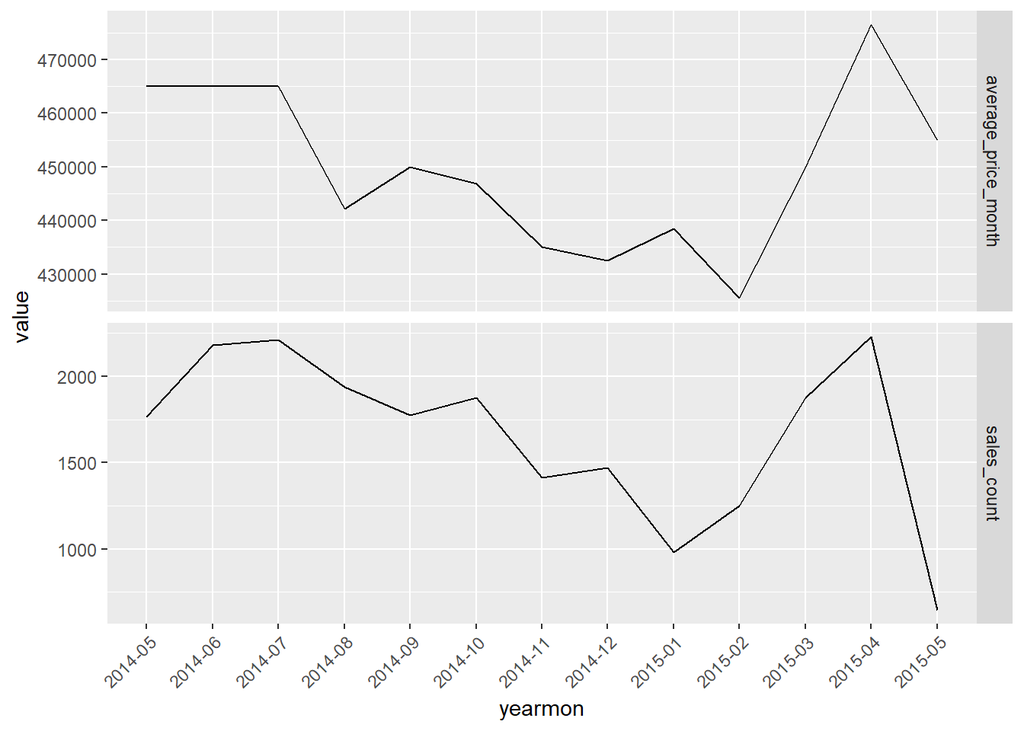

```r
df$month <- as.numeric(format(df$date,"%m"))
df$year <- as.numeric(format(df$date,"%Y"))
df$yearmon <- format(df$date,"%Y-%m")

sales_timeline <- df %>% group_by(yearmon) %>% summarize(average_price_month=median(price),sales_count=n()) %>% gather(key="key",value="value",average_price_month:sales_count)

ggplot(sales_timeline,aes(x=yearmon,y=value,group=1))+
  facet_grid(key~., scales="free_y")+
  geom_line()+
  theme(axis.text.x = element_text(angle = 45, hjust = 1))
```

In the figure, the top plot is “average price” vs “month-year” and the bottom plot is “no. of sales” vs “month-year”.

From 2014-05, the prices have been on a downward trend until 2015-02. From then on, the prices have been on an upward trend.

Therefore, *we shall not use date as an input variable. We will however check for auto-correlation using date as a variable.*

# Missing Values

```r
sum(!complete.cases(df))
```

```
## [1] 0
```

No missing values in data.

# Feature Engineering

## Geographic Location

The following graph plots the price on the geocordinates (latitude and longitude). It’s heatmap depicting the price - red being the lowest and green being the highest.

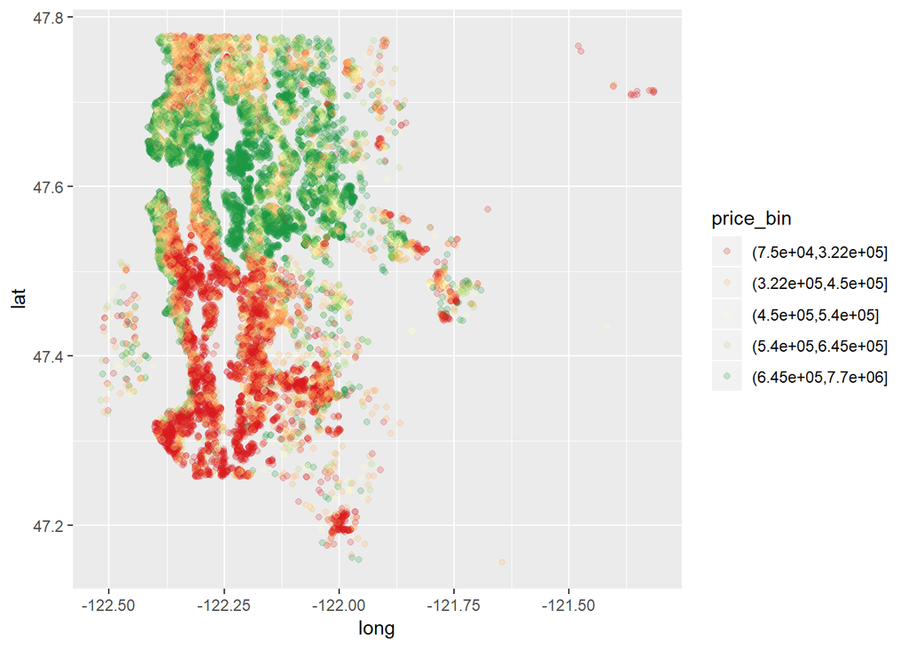

```r
df$price_bin <- cut(df$price,as.numeric(summary(df$price)))
ggplot(df[!is.na(df$price_bin),],aes(x=long,y=lat,color=price_bin))+
  geom_point(alpha=0.2)+
  scale_color_brewer(palette="RdYlGn")
```

The price is highest around the region $47.6^\circ$ lat and $-122.23^\circ$.

A new feature is created which measures the distance from the coordinates of the house that had the highest sales price.

```r
df <- df %>%
rowwise() %>%
mutate(distance = distHaversine(c(long, lat),
                                          c(-122.231,47.6176)))

df$max_lat <- df$lat[which(df$price==max(df$price))]
df$max_long <- df$long[which(df$price==max(df$price))]

df <- df %>%
rowwise() %>%
mutate(distance = distHaversine(c(long, lat),
                                          c(max_long,max_lat))) #%>% select(-max_lat,-max_long)
```

We can check how good this new feature is by measuring the correlation between it and the price.

```r
cor(df$distance,df$price)
```

```
## [1] -0.3197541
```

The correlation is moderate and this feature can be useful.

## Date Features

We have already created two variables - Year and Month.

```r
unique(df$year)
```

```
## [1] 2014 2015
```

```r
unique(df$month)
```

```
##  [1]  5  6  7  8  9 10 11 12  1  2  3  4
```

We will create the following features

- *Months from Feb 2015*: Absolute difference between sale date and Feb 2015 (in months)

_ *Months before Feb 2015*: No. of months the sales date is from Feb-2015. Zero if it is after Feb 2015

_ *Months after Feb 2015*: No. of months the sales date is after Feb-2015. Zero if it is before Feb 2015

These variables are created because the prices drop until Feb 2015 and then start rising after Feb-2015. We will use variable selection to understand what combination of “year”, “month” and the above three variables work best.

```r
df$months_from_feb2015 <- abs(round((as.yearmon(round(df$date))-as.yearmon("2015-02"))*12))
df$months_after_feb2015 <- pmax(round((as.yearmon(round(df$date))-as.yearmon("2015-02"))*12),0)
df$months_before_feb2015 <- df$months_after_feb2015 <- pmax(round((as.yearmon("2015-02")-as.yearmon(round(df$date)))*12),0)
```

## Age of house at sale

Age (in years), define as Sales “Date” - “Year Built”.

Some houses were sold before the year build, possibly they were sold *while* still under construction. Hence a lower limit of zero is imposed in the formula

```r
df$age <- max(year(df$date)-df$yr_built,0)
```

# Modelling and Variable Selection

## Train / Test Split

A 70% training and 30% test split is done

```r
set.seed(1)
training.fraction <- 0.7
train.index <- sample(nrow(df),nrow(df)*training.fraction)

df.train <- df[train.index,]
df.train <- df[order(df.train$date),]
df.test <- df[-train.index,]
```

## Full model

The full model will include all variables except the following:

- **id**: It’s a row identifier and doesn’t make sense to include in the model
- **date**: Other derived variables like “year”,“month” and months from Feb-2015 etc are used, so date is not used
- **sqft_basement*: This variable is perfectly multicolinear
- **zipcode**: Instead of zipcode, lat-long and “distance” from the most expensive sale are used
- **age**: It is perfectly linear combination of “Year built” and “Year” (of sale)
- **Months before/from Feb 2015**: They are a linear combination of “Months after Feb 2015” and “month”.

All other variables from the dataset have been included in the full model. Full model below

```r
m.full.1<- lm(price~bedrooms+
               bathrooms+
               sqft_living+
               sqft_lot+
               floors+
               waterfront+
               view+
               condition+
               grade+
               sqft_above+
               #sqft_basement+
               yr_built+
               yr_renovated+
               lat+
               long+
               sqft_lot15+
               year+
               #month+
               distance+
               #age+
               months_after_feb2015,
               #months_before_feb2015+
               #months_from_feb2015,
             data=df.train)
summary(m.full.1)
```

```
##
## Call:
## lm(formula = price ~ bedrooms + bathrooms + sqft_living + sqft_lot +
##     floors + waterfront + view + condition + grade + sqft_above +
##     yr_built + yr_renovated + lat + long + sqft_lot15 + year +
##     distance + months_after_feb2015, data = df.train)
##
## Residuals:
##      Min       1Q   Median       3Q      Max
## -1065486   -91763   -10469    70951  4251603
##
## Coefficients:
##                        Estimate Std. Error t value Pr(>|t|)
## (Intercept)           4.586e+07  1.886e+07   2.432  0.01504 *
## bedrooms             -3.410e+04  2.083e+03 -16.369  < 2e-16 ***
## bathrooms             3.331e+04  3.630e+03   9.175  < 2e-16 ***
## sqft_living           1.381e+02  4.791e+00  28.820  < 2e-16 ***
## sqft_lot              1.611e-01  5.866e-02   2.746  0.00605 **
## floors               -3.563e+04  4.051e+03  -8.797  < 2e-16 ***
## waterfront            6.264e+05  1.909e+04  32.813  < 2e-16 ***
## view                  5.407e+04  2.375e+03  22.770  < 2e-16 ***
## condition             3.420e+04  2.599e+03  13.160  < 2e-16 ***
## grade                 8.243e+04  2.343e+03  35.188  < 2e-16 ***
## sqft_above            7.624e+01  4.871e+00  15.652  < 2e-16 ***
## yr_built             -1.402e+03  8.389e+01 -16.715  < 2e-16 ***
## yr_renovated          2.930e+01  3.988e+00   7.345 2.16e-13 ***
## lat                  -1.162e+05  1.896e+04  -6.128 9.10e-10 ***
## long                  4.068e+05  1.709e+04  23.800  < 2e-16 ***
## sqft_lot15           -4.277e-02  8.534e-02  -0.501  0.61624
## year                  5.879e+03  9.274e+03   0.634  0.52614
## distance             -1.380e+01  3.072e-01 -44.917  < 2e-16 ***
## months_after_feb2015 -2.071e+02  7.094e+02  -0.292  0.77030
## ---
## Signif. codes:  0 '***' 0.001 '**' 0.01 '*' 0.05 '.' 0.1 ' ' 1
##
## Residual standard error: 189200 on 15110 degrees of freedom
## Multiple R-squared:  0.7385, Adjusted R-squared:  0.7382
## F-statistic:  2371 on 18 and 15110 DF,  p-value: < 2.2e-16
```

$C_p$ value is the lowest for the full model as seen in the plot below:

```r
x <- cbind(df.train$bedrooms,
df.train$bathrooms,
df.train$sqft_living,
df.train$sqft_lot,
df.train$floors,
df.train$waterfront,
df.train$view,
df.train$condition,
df.train$grade,
df.train$sqft_above,
df.train$yr_built,
df.train$yr_renovated,
df.train$lat,
df.train$long,
df.train$sqft_lot15,
df.train$year,
df.train$distance,
df.train$months_after_feb2015)

y <- df.train$price
m.leaps <- leaps(x,y,method='Cp')
leaps.cp <- data.frame(size=m.leaps$size,Cp=m.leaps$Cp)
leaps.cp <- inner_join(leaps.cp,leaps.cp %>% group_by(size) %>% summarize(Cp_min=min(Cp))) %>% mutate(is_min=Cp==Cp_min)
```

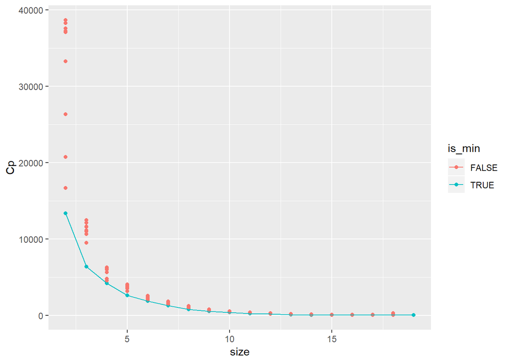

```r
ggplot(data=leaps.cp,aes(x=size,y=Cp,color=is_min,group=is_min))+
  geom_point()+
  geom_line(data=leaps.cp[leaps.cp$is_min,])
```

```r
m.leaps.r2 <- leaps(x,y,method='r2')
leaps.r2 <- data.frame(size=m.leaps.r2$size,r2=m.leaps.r2$r2)
leaps.r2 <- inner_join(leaps.r2,leaps.r2 %>% group_by(size) %>% summarize(r2_max=max(r2))) %>% mutate(is_max=r2==r2_max)
```

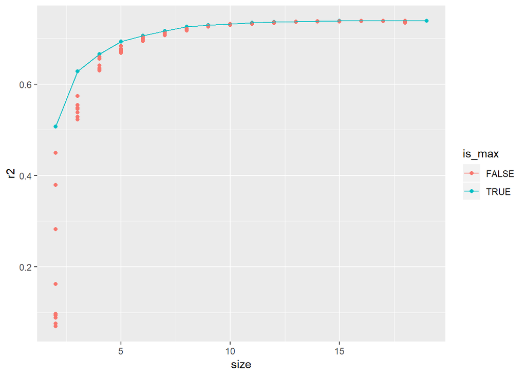

```r
ggplot(data=leaps.r2,aes(x=size,y=r2,color=is_max,group=is_max))+
  geom_point()+
  geom_line(data=leaps.r2[leaps.r2$is_max,])
```

$R^2$ flattens after 10 variables. If a simpler model is required, this model can be chosen as there’s a difference of ~1% between the reduced and the full model.

However, here we have preferred the full model with the assumption that this increase of 1% is worthwhile.

We’ll validate this thinking by checking the AIC of the models.

```r
m.aic.both <- ols_step_both_aic(m.full.1)
```

```
## Stepwise Selection Method
## -------------------------
##
## Candidate Terms:
##
## 1 . bedrooms
## 2 . bathrooms
## 3 . sqft_living
## 4 . sqft_lot
## 5 . floors
## 6 . waterfront
## 7 . view
## 8 . condition
## 9 . grade
## 10 . sqft_above
## 11 . yr_built
## 12 . yr_renovated
## 13 . lat
## 14 . long
## 15 . sqft_lot15
## 16 . year
## 17 . distance
## 18 . months_after_feb2015
##
##
## Variables Entered/Removed:
##
## - sqft_living added
## - distance added
## - waterfront added
## - grade added
## - yr_built added
## - long added
## - view added
## - bedrooms added
## - condition added
## - sqft_above added
## - bathrooms added
## - floors added
## - yr_renovated added
## - lat added
## - sqft_lot added
##
## No more variables to be added or removed.
```

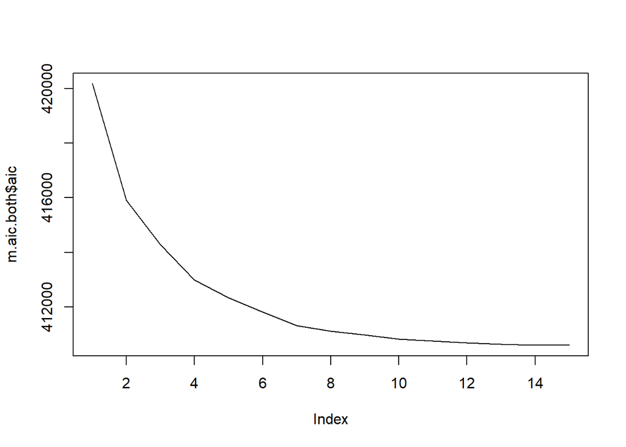

```r
plot(m.aic.both$aic,type="l")
```

```r
m.aic.back <- ols_step_backward_aic(m.full.1)
```

```
## Backward Elimination Method
## ---------------------------
##
## Candidate Terms:
##
## 1 . bedrooms
## 2 . bathrooms
## 3 . sqft_living
## 4 . sqft_lot
## 5 . floors
## 6 . waterfront
## 7 . view
## 8 . condition
## 9 . grade
## 10 . sqft_above
## 11 . yr_built
## 12 . yr_renovated
## 13 . lat
## 14 . long
## 15 . sqft_lot15
## 16 . year
## 17 . distance
## 18 . months_after_feb2015
##
##
## Variables Removed:
##
## - months_after_feb2015
## - sqft_lot15
## - year
##
## No more variables to be removed.
```

Since AIC is lower without “sqft_lot15” and it was also not a significant variable in the full model, *it is dropped in the final model* below.

```r
m.2 <- lm(price~bedrooms+
               bathrooms+
               sqft_living+
               sqft_lot+
               floors+
               waterfront+
               view+
               condition+
               grade+
               sqft_above+
               #sqft_basement+
               yr_built+
               yr_renovated+
               lat+
               long+
               #sqft_lot15+
               year+
               #month+
               distance+
               #age+
               months_after_feb2015,
               #months_before_feb2015+
               #months_from_feb2015,
             data=df.train)
summary(m.2)
```

```
##
## Call:
## lm(formula = price ~ bedrooms + bathrooms + sqft_living + sqft_lot +
##     floors + waterfront + view + condition + grade + sqft_above +
##     yr_built + yr_renovated + lat + long + year + distance +
##     months_after_feb2015, data = df.train)
##
## Residuals:
##      Min       1Q   Median       3Q      Max
## -1065661   -91756   -10440    70944  4252599
##
## Coefficients:
##                        Estimate Std. Error t value Pr(>|t|)
## (Intercept)           4.581e+07  1.886e+07   2.429 0.015149 *
## bedrooms             -3.406e+04  2.081e+03 -16.363  < 2e-16 ***
## bathrooms             3.336e+04  3.629e+03   9.192  < 2e-16 ***
## sqft_living           1.380e+02  4.787e+00  28.825  < 2e-16 ***
## sqft_lot              1.407e-01  4.239e-02   3.320 0.000903 ***
## floors               -3.559e+04  4.049e+03  -8.788  < 2e-16 ***
## waterfront            6.263e+05  1.909e+04  32.812  < 2e-16 ***
## view                  5.406e+04  2.375e+03  22.768  < 2e-16 ***
## condition             3.418e+04  2.599e+03  13.155  < 2e-16 ***
## grade                 8.242e+04  2.342e+03  35.187  < 2e-16 ***
## sqft_above            7.622e+01  4.871e+00  15.649  < 2e-16 ***
## yr_built             -1.402e+03  8.388e+01 -16.711  < 2e-16 ***
## yr_renovated          2.928e+01  3.988e+00   7.342 2.21e-13 ***
## lat                  -1.168e+05  1.893e+04  -6.171 6.96e-10 ***
## long                  4.067e+05  1.709e+04  23.796  < 2e-16 ***
## year                  5.909e+03  9.274e+03   0.637 0.524050
## distance             -1.381e+01  3.059e-01 -45.149  < 2e-16 ***
## months_after_feb2015 -2.081e+02  7.094e+02  -0.293 0.769290
## ---
## Signif. codes:  0 '***' 0.001 '**' 0.01 '*' 0.05 '.' 0.1 ' ' 1
##
## Residual standard error: 189200 on 15111 degrees of freedom
## Multiple R-squared:  0.7385, Adjusted R-squared:  0.7382
## F-statistic:  2510 on 17 and 15111 DF,  p-value: < 2.2e-16
```

# Model Diagnostics

## Accuracy on test data

```r
get_mape <- function(model){
df.train.predict <- predict(model)
df.test.predicted <- predict(model,newdata=df.test)
mape <- mean(abs(df.test.predicted-df.test$price)/df.test$price)
}
print(get_mape(m.2))
```

```
## [1] 0.2477318
```

## Appropriateness of the linear function

Functional form of the two variables that entered regression first - “Sqft Living” and “Distance” is determined below

### Price vs Sqft Living Relationship

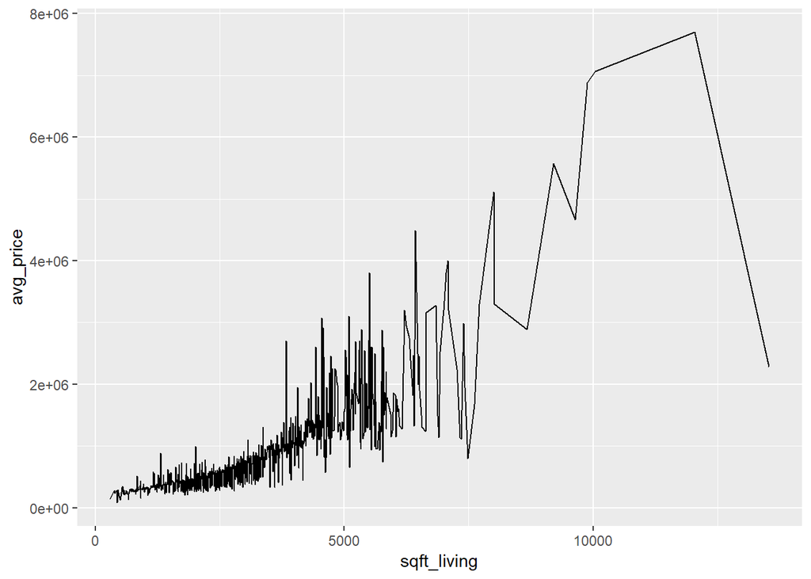

```r
ggplot(df.train %>% mutate(sqft_living=sqft_living) %>% group_by(sqft_living) %>% summarize(avg_price=mean(price)) ,aes(x=sqft_living,y=avg_price,group=1))+
  geom_line()
```

```r
m.part.1 <- lm(price~sqft_living,data=df.train)
m.part.2 <- lm(price~sqft_living+I(sqft_living^2),data=df.train)
```

Since there are too many data points, the average price for each sqft_living is plotted. A polynomial form which includes $sqft\_living^2$ is approporate.

It is scaled and added in the model below.

```r
df.train$sqft_living_scaled <- df.train$sqft_living-mean(df$sqft_living)
df.test$sqft_living_scaled <- df.test$sqft_living-mean(df$sqft_living)
m.3 <- lm(price~bedrooms+
               bathrooms+
               sqft_living_scaled+
              I(sqft_living_scaled^2)+
               sqft_lot+
               floors+
               waterfront+
               view+
               condition+
               grade+
               sqft_above+
               #sqft_basement+
               yr_built+
               yr_renovated+
               lat+
               long+
               #sqft_lot15+
               year+
               #month+
               distance+
               #age+
               months_after_feb2015,
               #months_before_feb2015+
               #months_from_feb2015,
             data=df.train)
summary(m.3)
```

```
##
## Call:
## lm(formula = price ~ bedrooms + bathrooms + sqft_living_scaled +
##     I(sqft_living_scaled^2) + sqft_lot + floors + waterfront +
##     view + condition + grade + sqft_above + yr_built + yr_renovated +
##     lat + long + year + distance + months_after_feb2015, data = df.train)
##
## Residuals:
##      Min       1Q   Median       3Q      Max
## -4444956   -84687   -10956    66044  2466170
##
## Coefficients:
##                           Estimate Std. Error t value Pr(>|t|)
## (Intercept)              4.972e+07  1.781e+07   2.792  0.00525 **
## bedrooms                -1.452e+04  2.017e+03  -7.196 6.48e-13 ***
## bathrooms                3.676e+04  3.427e+03  10.725  < 2e-16 ***
## sqft_living_scaled       7.271e+01  4.768e+00  15.249  < 2e-16 ***
## I(sqft_living_scaled^2)  3.207e-02  7.474e-04  42.913  < 2e-16 ***
## sqft_lot                 8.859e-02  4.004e-02   2.212  0.02696 *
## floors                  -2.549e+04  3.830e+03  -6.656 2.92e-11 ***
## waterfront               5.982e+05  1.803e+04  33.170  < 2e-16 ***
## view                     5.187e+04  2.243e+03  23.131  < 2e-16 ***
## condition                3.972e+04  2.457e+03  16.166  < 2e-16 ***
## grade                    9.439e+04  2.229e+03  42.345  < 2e-16 ***
## sqft_above               6.356e+01  4.608e+00  13.794  < 2e-16 ***
## yr_built                -1.261e+03  7.926e+01 -15.912  < 2e-16 ***
## yr_renovated             3.440e+01  3.767e+00   9.131  < 2e-16 ***
## lat                     -8.677e+04  1.788e+04  -4.851 1.24e-06 ***
## long                     4.210e+05  1.614e+04  26.087  < 2e-16 ***
## year                     4.030e+03  8.756e+03   0.460  0.64534
## distance                -1.312e+01  2.893e-01 -45.363  < 2e-16 ***
## months_after_feb2015    -3.215e+02  6.698e+02  -0.480  0.63127
## ---
## Signif. codes:  0 '***' 0.001 '**' 0.01 '*' 0.05 '.' 0.1 ' ' 1
##
## Residual standard error: 178600 on 15110 degrees of freedom
## Multiple R-squared:  0.7669, Adjusted R-squared:  0.7666
## F-statistic:  2762 on 18 and 15110 DF,  p-value: < 2.2e-16
```

The **F-test** below shows that adding the sqauared term for sqft_living is statisstically significant.

```r
anova(m.2,m.3)
```

|  | Res.Df | RSS | Df | Sum of Sq | F | Pr(>F) |
| --- | --- | --- | --- | --- | --- | --- |
| 1 | 15111 | 5.409829e+14 | NA | NA | NA | NA |
| 2 | 15110 | 4.822135e+14 | 1 | 5.876941e+13 | 1841.52 | 0 |

Next, the appropriate relationship for “distance” is identified. “Distance” is regressed on second order of “sqft_living” and “price” is also regressed on second order of “sqft_living”. The two residuals of distance are aggregated and plotted against the residuals or price.

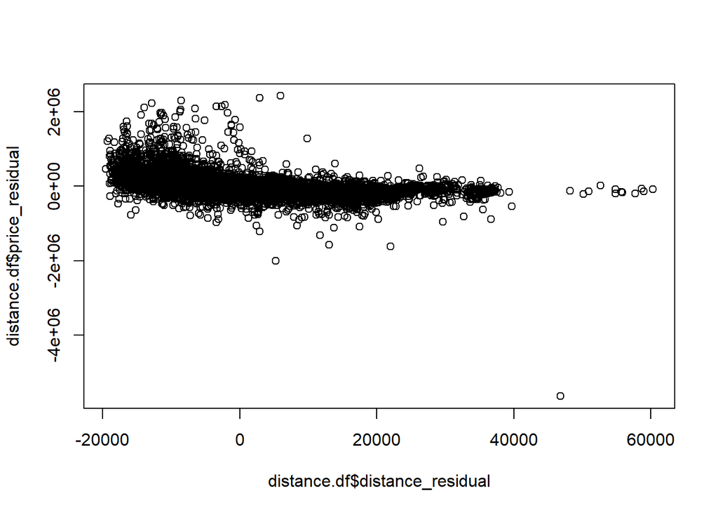

```r
distance.df <- data.frame(price=df.train$price,distance=df.train$distance,price_residual=m.part.2$residuals,distance_residual=lm(distance~sqft_living+I(sqft_living^2),data=df.train)$residuals,m3_residual=m.3$residuals)

plot(distance.df$distance_residual,distance.df$price_residual)
```

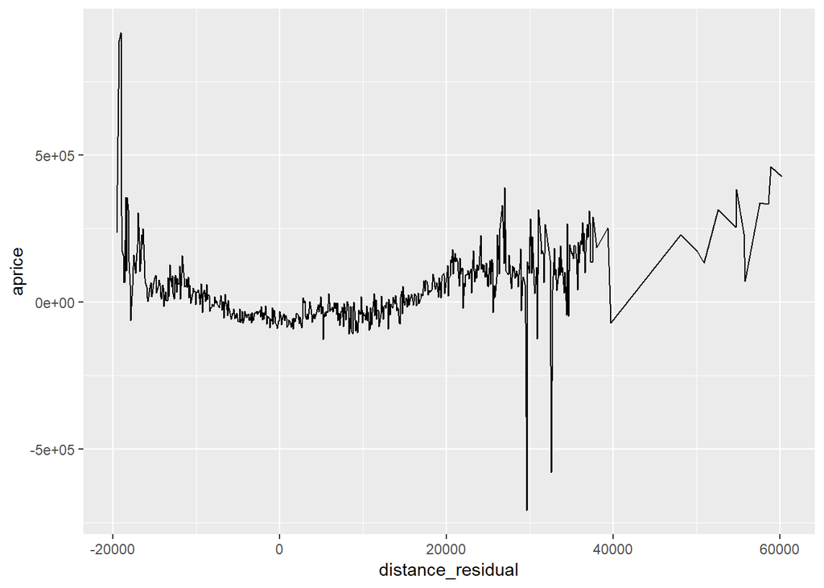

```r
ggplot(distance.df %>% mutate(distance_residual=(distance_residual%/%100)*100)%>% group_by(distance_residual) %>% summarize(aprice=mean(m3_residual),mprice=median(m3_residual)) %>% filter(aprice>-2500000),aes(x=distance_residual,y=aprice,group=1))+
  geom_line()
```

There appears to be a “U-shaped” relationship. Adding a second order term for “distance” would be appropriate.

Distance is scaled and the second order term added below:

```r
df.train$distance_scaled <- df.train$distance-mean(df.train$distance)
df.test$distance_scaled <- df.test$distance-mean(df.train$distance)
m.4 <- lm(price~bedrooms+
               bathrooms+
               sqft_living_scaled+
              I(sqft_living_scaled^2)+
               sqft_lot+
               floors+
               waterfront+
               view+
               condition+
               grade+
               sqft_above+
               #sqft_basement+
               yr_built+
               yr_renovated+
               lat+
               long+
               #sqft_lot15+
               year+
               #month+
               distance_scaled+
            I(distance_scaled^2)+
               #age+
               months_after_feb2015,
               #months_before_feb2015+
               #months_from_feb2015,
             data=df.train)
summary(m.4)
```

```
##
## Call:
## lm(formula = price ~ bedrooms + bathrooms + sqft_living_scaled +
##     I(sqft_living_scaled^2) + sqft_lot + floors + waterfront +
##     view + condition + grade + sqft_above + yr_built + yr_renovated +
##     lat + long + year + distance_scaled + I(distance_scaled^2) +
##     months_after_feb2015, data = df.train)
##
## Residuals:
##      Min       1Q   Median       3Q      Max
## -4256803   -80452    -7053    65387  2411072
##
## Coefficients:
##                           Estimate Std. Error t value Pr(>|t|)
## (Intercept)              3.568e+07  1.714e+07   2.081  0.03742 *
## bedrooms                -1.153e+04  1.944e+03  -5.931 3.08e-09 ***
## bathrooms                2.964e+04  3.305e+03   8.967  < 2e-16 ***
## sqft_living_scaled       7.084e+01  4.590e+00  15.432  < 2e-16 ***
## I(sqft_living_scaled^2)  3.049e-02  7.209e-04  42.299  < 2e-16 ***
## sqft_lot                 6.464e-02  3.855e-02   1.677  0.09361 .
## floors                  -6.152e+04  3.831e+03 -16.057  < 2e-16 ***
## waterfront               6.389e+05  1.740e+04  36.720  < 2e-16 ***
## view                     4.921e+04  2.160e+03  22.782  < 2e-16 ***
## condition                4.188e+04  2.366e+03  17.702  < 2e-16 ***
## grade                    8.638e+04  2.158e+03  40.023  < 2e-16 ***
## sqft_above               9.065e+01  4.504e+00  20.128  < 2e-16 ***
## yr_built                -4.482e+02  7.983e+01  -5.615 2.00e-08 ***
## yr_renovated             3.670e+01  3.627e+00  10.119  < 2e-16 ***
## lat                     -5.363e+04  1.724e+04  -3.110  0.00187 **
## long                     4.023e+05  1.554e+04  25.882  < 2e-16 ***
## year                     8.175e+03  8.429e+03   0.970  0.33213
## distance_scaled         -1.674e+01  2.974e-01 -56.294  < 2e-16 ***
## I(distance_scaled^2)     3.282e-04  9.479e-06  34.625  < 2e-16 ***
## months_after_feb2015     9.091e+00  6.448e+02   0.014  0.98875
## ---
## Signif. codes:  0 '***' 0.001 '**' 0.01 '*' 0.05 '.' 0.1 ' ' 1
##
## Residual standard error: 172000 on 15109 degrees of freedom
## Multiple R-squared:  0.784,  Adjusted R-squared:  0.7838
## F-statistic:  2887 on 19 and 15109 DF,  p-value: < 2.2e-16
```

The **F-test** below shows that adding the sqauared term for distance is statisstically significant.

```r
anova(m.3,m.4)
```

|  | Res.Df | RSS | Df | Sum of Sq | F | Pr(>F) |
| --- | --- | --- | --- | --- | --- | --- |
| 1 | 15110 | 4.822135e+14 | NA | NA | NA | NA |
| 2 | 15109 | 4.467622e+14 | 1 | 3.545129e+13 | 1198.923 | 7.06895e-253 |

## Error variance

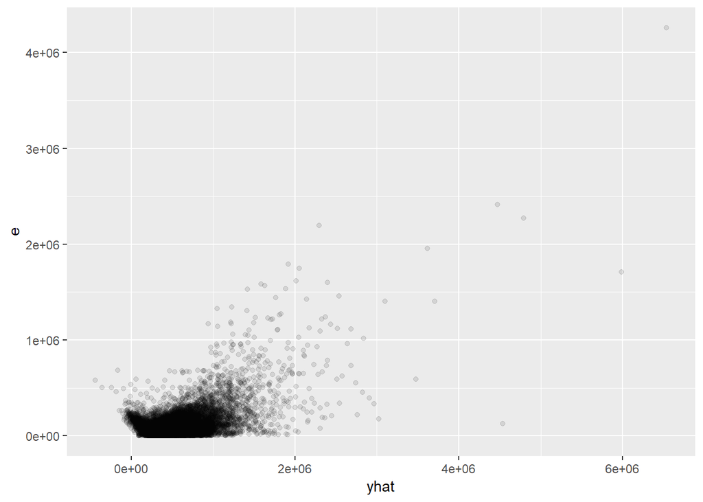

```r
ggplot(data.frame(yhat=predict(m.4),e=abs(m.4$residuals)),aes(x=yhat,y=e))+geom_point(alpha=0.1)
```

Severe heteroscadsticity can be observed in the errors.

*Brown Forsythe Test*

```r
brown_forsythe <- function(lm_model){
  ei<-lm_model$residuals

  yhat <- predict(lm_model)


    DM<-data.frame(cbind(yhat,ei))
    DM1<-DM[DM[,1]<=median(yhat),]
    DM2<-DM[DM[,1]>median(yhat),]

    M1<-summary(DM1[,2])
    M2<-summary(DM2[,2])
    N1<-length(DM1[,2])
    N2<-length(DM2[,2])


    d1<-abs(DM1[,2]-M1[3])
    d2<-abs(DM2[,2]-M2[3])

    s2<-sqrt((var(d1)*(N1-1)+var(d2)*(N2-1))/(N1+N2-2))



    Den<- s2*sqrt(1/N1+1/N2)
    Num<- mean(d1)-mean(d2)


    T= Num/Den
    T

}

print(abs(brown_forsythe(m.4)))
```

```
## [1] 29.90706
```

```r
print(qt(1-0.01/2,nrow(df.train)))
```

```
## [1] 2.576154
```

The t-value for Brown Forsythe Test is very high (much higher than the critical t-value) and so we conclude that the error variance is not constant.

**Boxcox transformation** to identify best transformation.

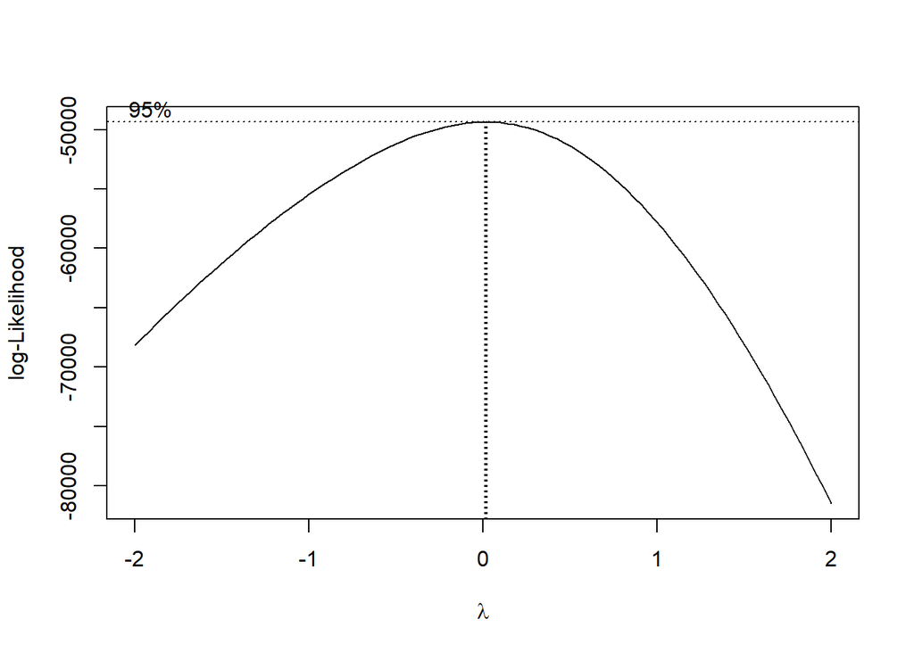

```r
boxcox(m.4)
```

Lambda = 0, so best transformation is log(Y).

Log(Price) instead of “price” is used as the dependent variable henceforth.

```r
m.5 <- lm(log(price)~bedrooms+
               bathrooms+
               sqft_living_scaled+
              I(sqft_living_scaled^2)+
               sqft_lot+
               floors+
               waterfront+
               view+
               condition+
               grade+
               sqft_above+
               #sqft_basement+
               yr_built+
               yr_renovated+
               lat+
               long+
               #sqft_lot15+
               year+
               #month+
               distance_scaled+
            I(distance_scaled^2)+
               #age+
               months_after_feb2015,
               #months_before_feb2015+
               #months_from_feb2015,
             data=df.train)
summary(m.5)
```

```
##
## Call:
## lm(formula = log(price) ~ bedrooms + bathrooms + sqft_living_scaled +
##     I(sqft_living_scaled^2) + sqft_lot + floors + waterfront +
##     view + condition + grade + sqft_above + yr_built + yr_renovated +
##     lat + long + year + distance_scaled + I(distance_scaled^2) +
##     months_after_feb2015, data = df.train)
##
## Residuals:
##      Min       1Q   Median       3Q      Max
## -1.51201 -0.12419  0.00465  0.12951  1.37025
##
## Coefficients:
##                           Estimate Std. Error t value Pr(>|t|)
## (Intercept)              7.093e+01  2.118e+01   3.348 0.000815 ***
## bedrooms                -1.776e-02  2.402e-03  -7.397 1.47e-13 ***
## bathrooms                4.119e-02  4.084e-03  10.086  < 2e-16 ***
## sqft_living_scaled       1.835e-04  5.672e-06  32.344  < 2e-16 ***
## I(sqft_living_scaled^2) -2.327e-08  8.908e-10 -26.122  < 2e-16 ***
## sqft_lot                 7.177e-07  4.763e-08  15.067  < 2e-16 ***
## floors                  -5.677e-02  4.734e-03 -11.993  < 2e-16 ***
## waterfront               4.851e-01  2.150e-02  22.564  < 2e-16 ***
## view                     6.737e-02  2.669e-03  25.243  < 2e-16 ***
## condition                7.487e-02  2.923e-03  25.615  < 2e-16 ***
## grade                    1.355e-01  2.667e-03  50.823  < 2e-16 ***
## sqft_above               1.116e-04  5.565e-06  20.045  < 2e-16 ***
## yr_built                -4.773e-04  9.864e-05  -4.839 1.32e-06 ***
## yr_renovated             5.195e-05  4.482e-06  11.592  < 2e-16 ***
## lat                      3.639e-01  2.130e-02  17.082  < 2e-16 ***
## long                     7.658e-01  1.921e-02  39.871  < 2e-16 ***
## year                     8.842e-03  1.042e-02   0.849 0.395920
## distance_scaled         -2.686e-05  3.675e-07 -73.069  < 2e-16 ***
## I(distance_scaled^2)     4.907e-10  1.171e-11  41.893  < 2e-16 ***
## months_after_feb2015     9.316e-04  7.967e-04   1.169 0.242309
## ---
## Signif. codes:  0 '***' 0.001 '**' 0.01 '*' 0.05 '.' 0.1 ' ' 1
##
## Residual standard error: 0.2125 on 15109 degrees of freedom
## Multiple R-squared:  0.8379, Adjusted R-squared:  0.8377
## F-statistic:  4110 on 19 and 15109 DF,  p-value: < 2.2e-16
```

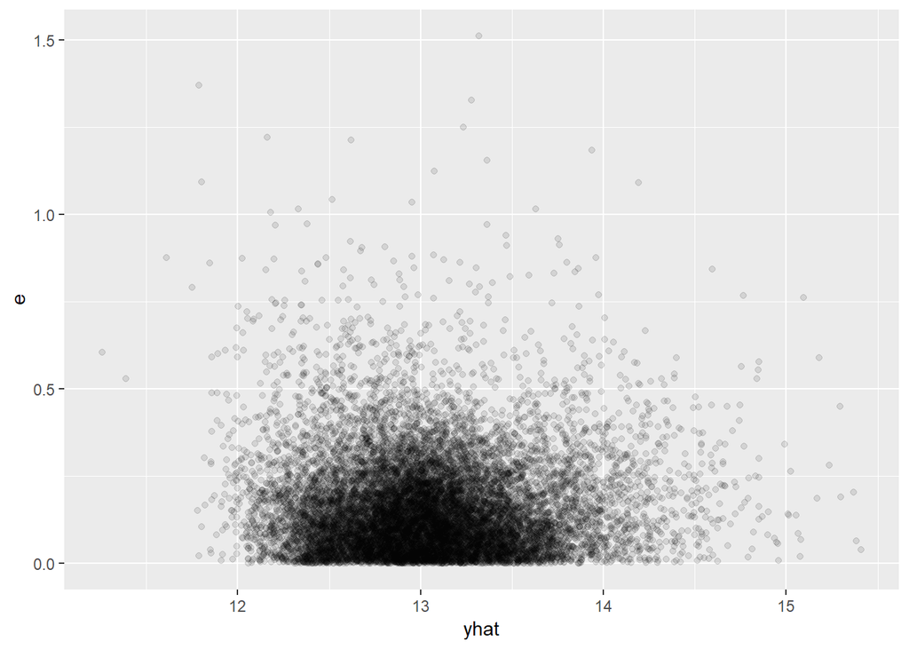

```r
ggplot(data.frame(yhat=predict(m.5),e=abs(m.5$residuals)),aes(x=yhat,y=e))+geom_point(alpha=0.1)
```

Error variance is much more stable now.

Brown-Froysthe test below on the new model.

```r
print(abs(brown_forsythe(m.5)))
```

```
## [1] 3.349198
```

```r
print(qt(1-0.01/2,nrow(df.train)))
```

```
## [1] 2.576154
```

Even though the t-value is still higher than the critical value, it has come down significantly from 29.9 to 3.34 . We will accept this model for constant error variance.

## Multicolinearity

```r
mult.df <- vif(m.5)
print(mult.df[order(-mult.df)])
```

```
##      sqft_living_scaled              sqft_above         distance_scaled
##                9.339071                7.263041                5.844420
##               bathrooms                   grade                     lat
##                3.340990                3.309953                2.884645
##                yr_built                    long                  floors
##                2.823184                2.470837                2.194427
##                bedrooms    I(distance_scaled^2) I(sqft_living_scaled^2)
##                1.718290                1.674161                1.611106
##                    view               condition              waterfront
##                1.417682                1.260244                1.218707
##            yr_renovated    months_after_feb2015                    year
##                1.159143                1.155519                1.152770
##                sqft_lot
##                1.136272
```

The new model with “year” and “month” dropped is as follows:

```r
m.6 <- lm(log(price)~bedrooms+
               bathrooms+
               sqft_living_scaled+
              I(sqft_living_scaled^2)+
               sqft_lot+
               floors+
               waterfront+
               view+
               condition+
               grade+
               sqft_above+
               #sqft_basement+
               yr_built+
               yr_renovated+
               lat+
               long+
               #sqft_lot15+
               #year+
               #month+
               distance_scaled+
            I(distance_scaled^2)+
               #age+
               months_after_feb2015,
               #months_before_feb2015+
               #months_from_feb2015,
             data=df.train)
summary(m.6)
```

```
##
## Call:
## lm(formula = log(price) ~ bedrooms + bathrooms + sqft_living_scaled +
##     I(sqft_living_scaled^2) + sqft_lot + floors + waterfront +
##     view + condition + grade + sqft_above + yr_built + yr_renovated +
##     lat + long + distance_scaled + I(distance_scaled^2) + months_after_feb2015,
##     data = df.train)
##
## Residuals:
##      Min       1Q   Median       3Q      Max
## -1.51110 -0.12408  0.00475  0.12977  1.37024
##
## Coefficients:
##                           Estimate Std. Error t value Pr(>|t|)
## (Intercept)              8.874e+01  3.000e+00  29.581  < 2e-16 ***
## bedrooms                -1.773e-02  2.401e-03  -7.385 1.61e-13 ***
## bathrooms                4.121e-02  4.084e-03  10.092  < 2e-16 ***
## sqft_living_scaled       1.834e-04  5.671e-06  32.337  < 2e-16 ***
## I(sqft_living_scaled^2) -2.326e-08  8.907e-10 -26.118  < 2e-16 ***
## sqft_lot                 7.181e-07  4.763e-08  15.076  < 2e-16 ***
## floors                  -5.682e-02  4.734e-03 -12.003  < 2e-16 ***
## waterfront               4.850e-01  2.150e-02  22.563  < 2e-16 ***
## view                     6.740e-02  2.669e-03  25.257  < 2e-16 ***
## condition                7.483e-02  2.923e-03  25.604  < 2e-16 ***
## grade                    1.355e-01  2.667e-03  50.830  < 2e-16 ***
## sqft_above               1.116e-04  5.565e-06  20.049  < 2e-16 ***
## yr_built                -4.777e-04  9.864e-05  -4.843 1.29e-06 ***
## yr_renovated             5.193e-05  4.482e-06  11.587  < 2e-16 ***
## lat                      3.639e-01  2.130e-02  17.081  < 2e-16 ***
## long                     7.658e-01  1.921e-02  39.868  < 2e-16 ***
## distance_scaled         -2.685e-05  3.675e-07 -73.066  < 2e-16 ***
## I(distance_scaled^2)     4.906e-10  1.171e-11  41.886  < 2e-16 ***
## months_after_feb2015     6.874e-04  7.430e-04   0.925    0.355
## ---
## Signif. codes:  0 '***' 0.001 '**' 0.01 '*' 0.05 '.' 0.1 ' ' 1
##
## Residual standard error: 0.2125 on 15110 degrees of freedom
## Multiple R-squared:  0.8379, Adjusted R-squared:  0.8377
## F-statistic:  4338 on 18 and 15110 DF,  p-value: < 2.2e-16
```

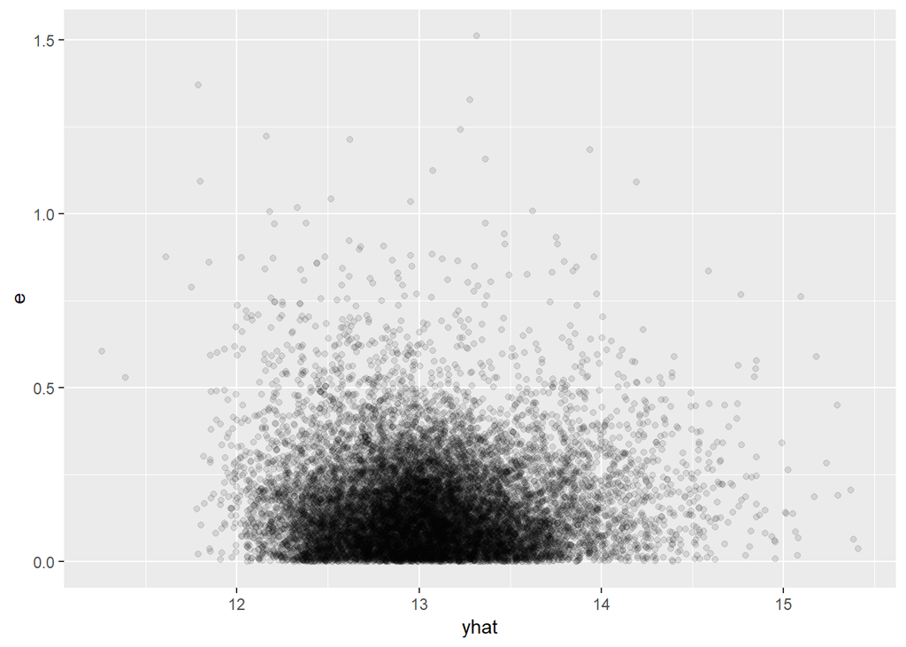

```r
ggplot(data.frame(yhat=predict(m.6),e=abs(m.6$residuals)),aes(x=yhat,y=e))+geom_point(alpha=0.1)
```

## Normality of Residuals

The Q-Q plot below.

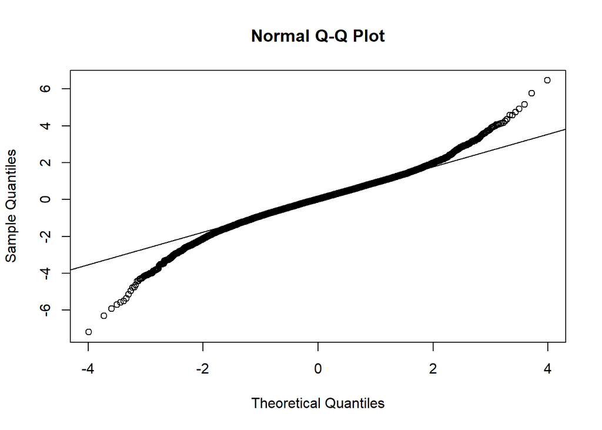

```r
qqnorm(rstandard(m.6))
qqline(rstandard(m.6))
```

There are no major departures from normality. The residuals are symmetric, although the tails are heavy.

## Autocorrelation

The residual plot against date do not show any system autocorrelation:

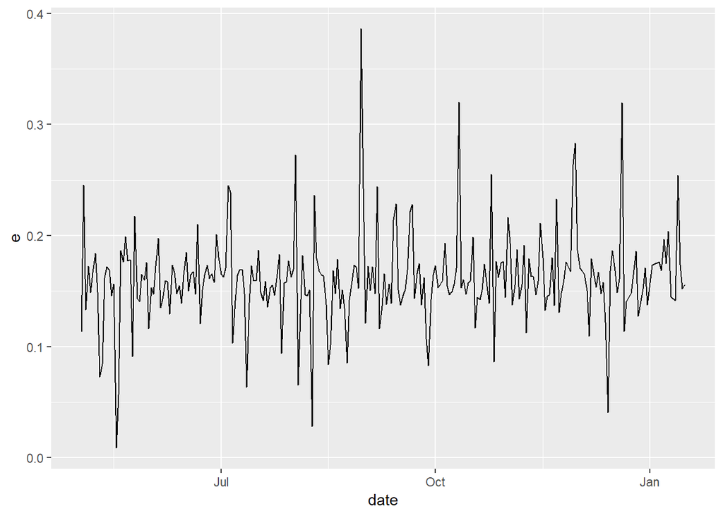

```r
auto.df <- data.frame(e=abs(m.6$residuals),date=df.train$date)
ggplot(auto.df %>% group_by(date) %>% summarize(e=mean(e)),aes(x=date,y=e,group=1))+
  geom_line()
```

The Durbin Watson test below also suggests no auto-correlation

```r
durbinWatsonTest(m.6)
```

```
##  lag Autocorrelation D-W Statistic p-value
##    1     -0.01119634      2.022314   0.158
##  Alternative hypothesis: rho != 0
```

Since the p-value (0.158) is greater than 0.05, we can accept the null and conclude that there is no significant autocorrelation